# Naches: exploring Bob’s comments about normalization approach for metabolism allometry

October 29, 2026

## Naches HUC8 as a test watershed

Naches (HUC8 17030002) is a familiar watershed with all GPP and most ER data intact, and it’s headwaters (not inheriting upstream inputs) so it will be our guinea pig:

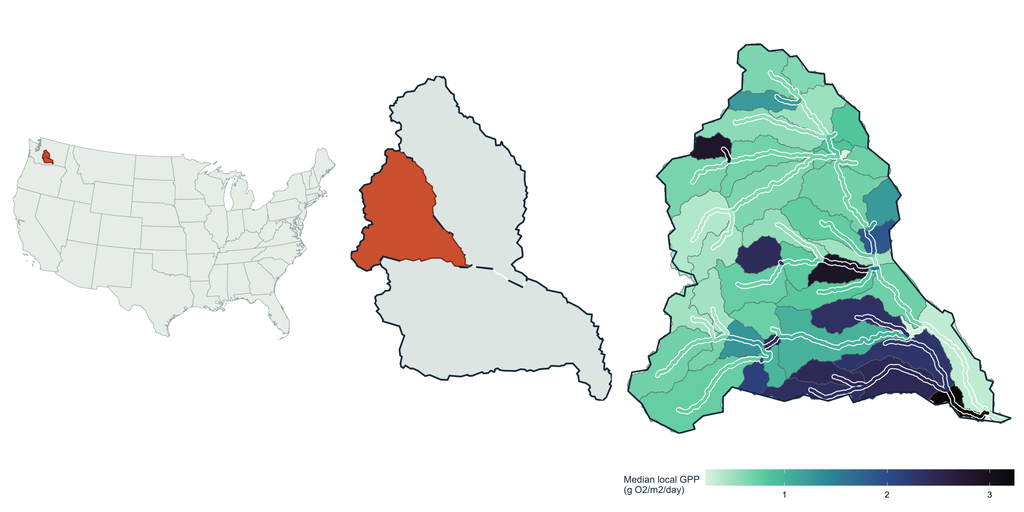

## Data distributions

First, a peek at the datasets we’re using for context. Note that Maavara et al. (2025) filtered out watersheds draining less than 25 km² for total drainage area upstream of a channel in the MERIT network (`uparea`), and we’re plotting the land area added locally at each reach (`unitarea`). For Naches, `unitarea` (11 of 51 are below 25 km²; `uparea` minimum here: 25.25 km²).

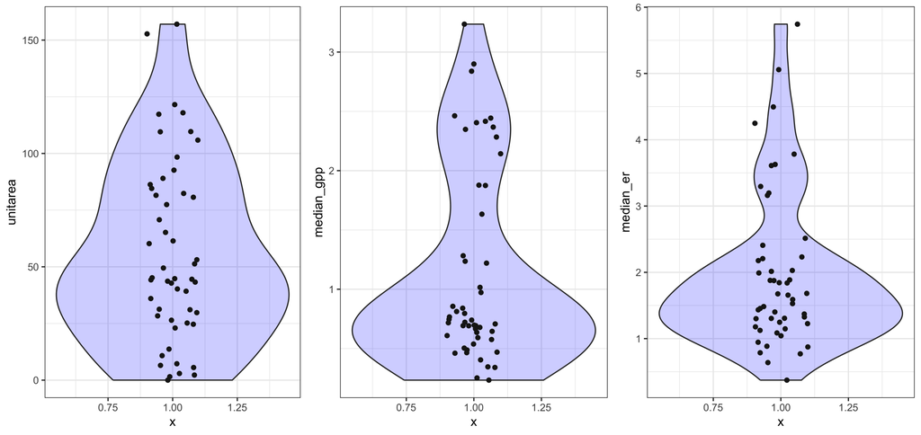

## Our current approach:

1. Process rate, either GPP or ER (`r`, g O2 / m2 / day), is normalized to stream surface area (`S`, m^2) to give us reach-integrated process rates (`R`, g O2 / day`)
2. Reach-integrated process rates (`R`) are accumulated downstream, as are contributing watershed areas (`A`). Note that all upstream rates/areas AND the reach rate/area are included here.
3. We regress `R` against `A` in log-log space and fit slopes for allometric scaling

You could write step 2 as
$$R=\sum_{i\in U}r_iS_i,\qquad A=\sum_{i\in U}A_i.$$
Which gives us this relationship (based on Wollheim et al. 2022 and Regier et al. 2025 normalization approaches):

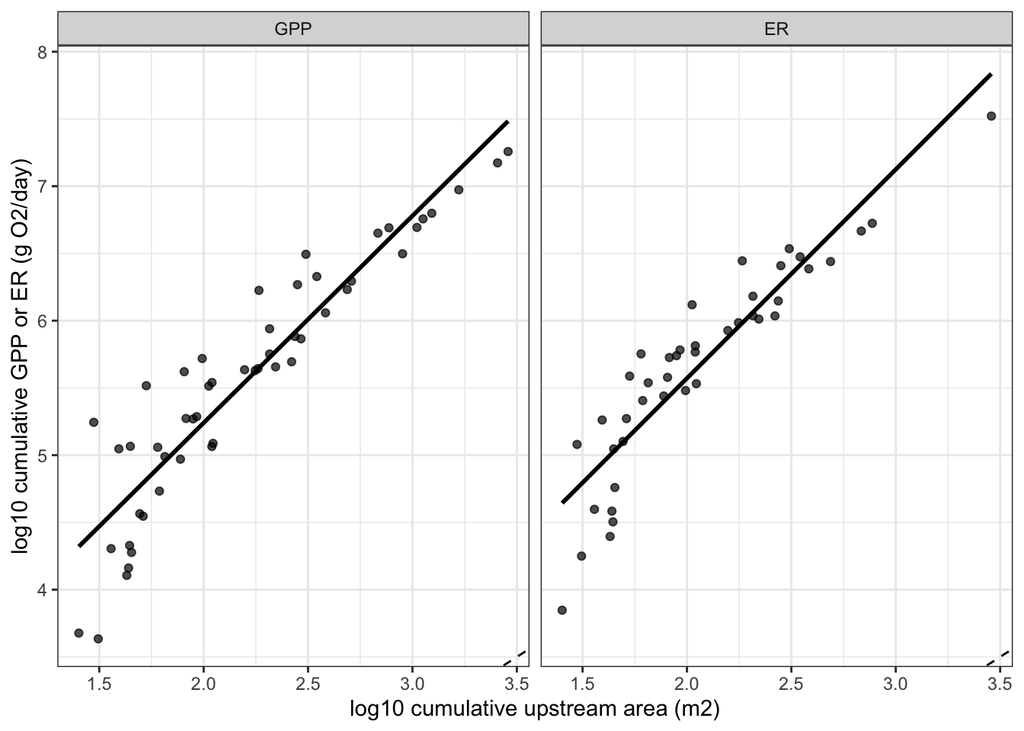

### Quick confirmation patterns are as expected…

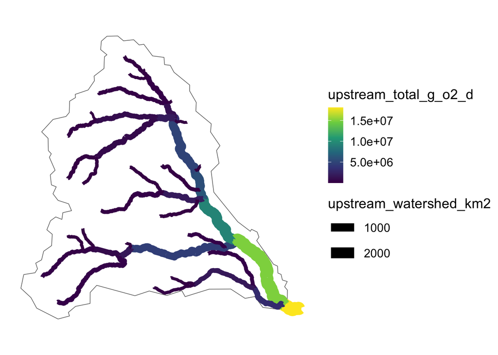

## Bob’s note:

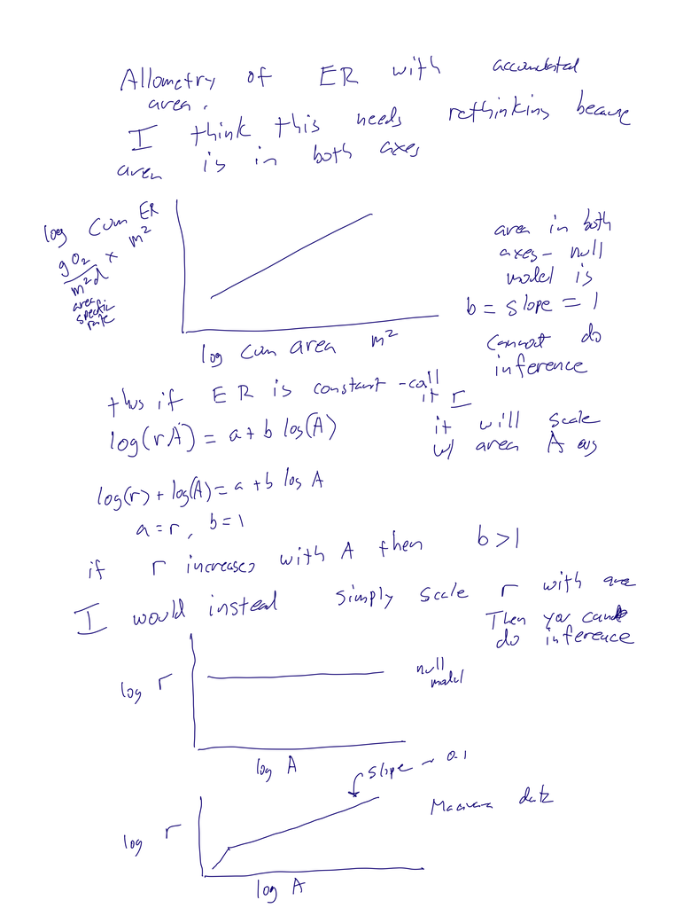

### Clarification on areas (`A` vs `S`)

As I read it, Bob’s note assumes we are normalizing our reach-scale rates (`r`) to watershed area (`A`). **Our calculations are normalizing to stream surface area (`S`), not watershed area (`A`)**. We are still normalizing to *an* area (`S`), **but** not to the same area as is on our x-axis (`A`).

## Walking through Bob’s proposal

### Step 1: If we normalized `r` by `A`, what would we have?

Similar to what Bob was suggesting, a slope close to 1

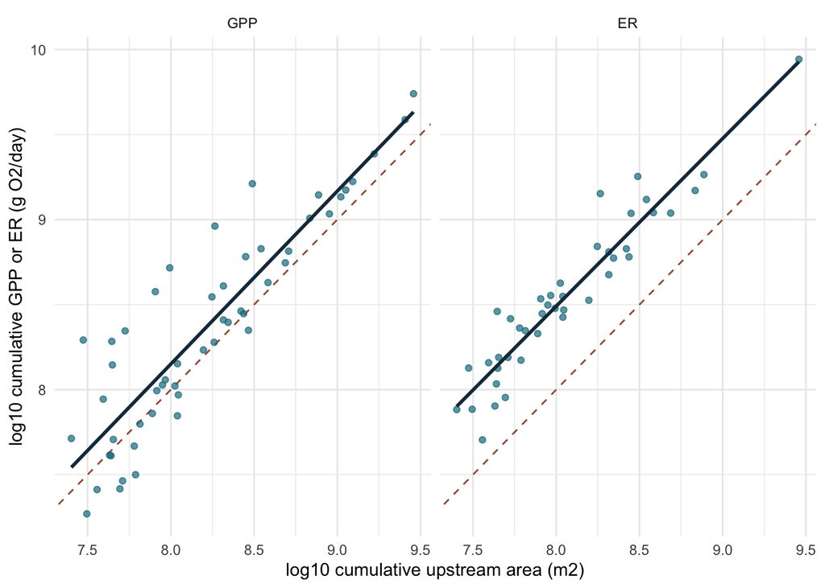

### Step 2: What if we just do cumulative rate (`r`) normalized to nothing?

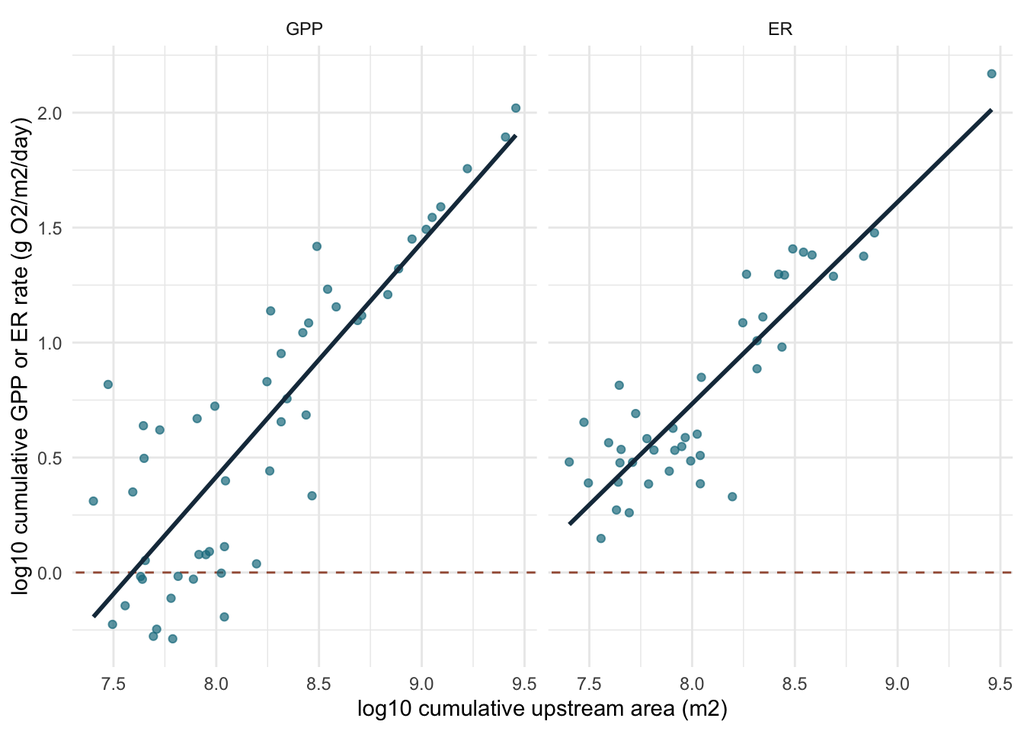

### Step 3: If we normalize to `S` instead of `A`, what do we get?

We aren’t directly comparing `r*A` vs `A`, but we are comparing an areal component (`S`) that correlates to `A`

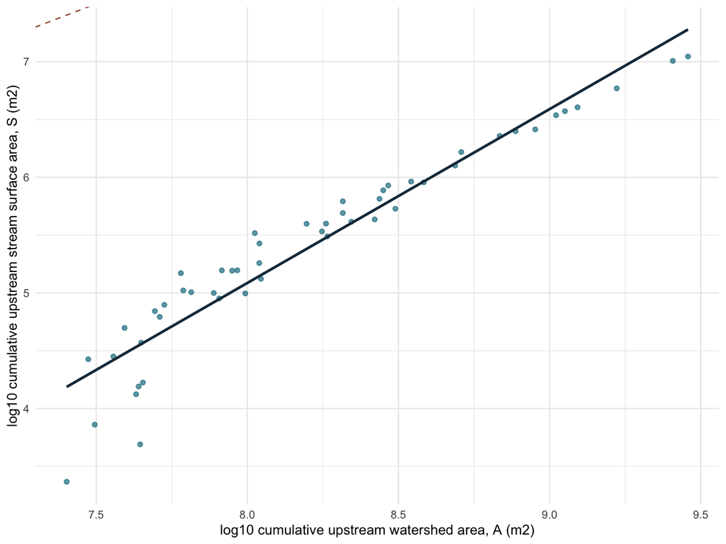

### Step 4: What scaling would we obtain with constant areal rates?

How much scaling would occur from accumulating stream surface area alone? For each process, we replace every valid July reach rate with one stream-area-weighted mean rate while keeping the Naches network and stream areas fixed.

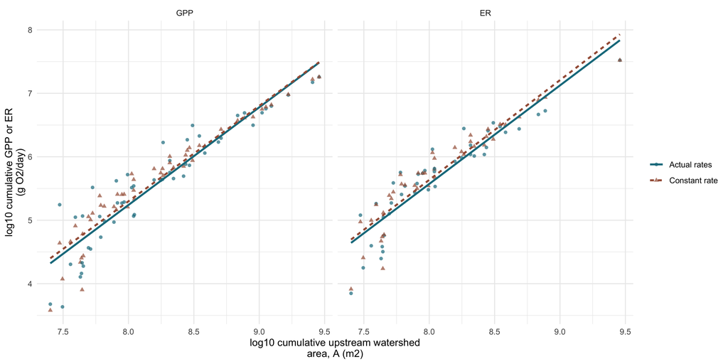

| Process | Actual slope | Constant-rate slope | Actual minus constant |
| --- | --- | --- | --- |
| GPP | 1.539 | 1.504 | 0.035 |
| ER | 1.553 | 1.573 | -0.020 |

The constant-rate totals closely reproduce the rising pattern and fitted slopes for both processes, while the actual totals have additional reach-to-reach scatter, most visibly at smaller watershed areas.

## My take-aways

### 1. We’re not using `A` in both x and y-axes, but

### 2. `S` is strongly correlated to `A`, meaning

### 3. We need to be careful about over-interpreting the impact of `R` vs `S` on scaling, and

### 4. Scaling is largely controlled by accumulating area, less by metabolism